## Моделирование ряда вида кусочно-линейный (тренд) + броуновское движение (шум)

Параметры:

- интенсивность изломов $\lambda$
- дисперсия $\sigma_a^2$ тангеса угла наклона тренда, распределенного нормально со средним 0
- дисперсия $\sigma^2$ приращения в броуновском движении

#### Моделирование броуновского движения

Дискретная производная броуновского движения — белый шум. Тогда для моделирования броуновского движения нужно взять накопленную сумму белого шума.

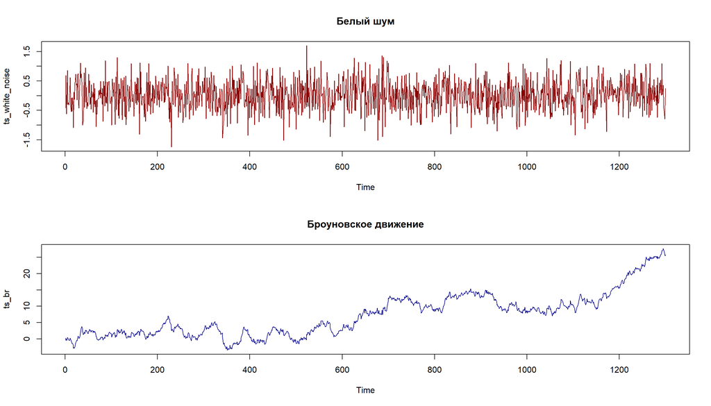

```r
set.seed(5)
n <- 1300

sd <- 0.5
mean <- 0

ts_white_noise <- ts(rnorm(n, mean = mean, sd = sd))
ts_br <- ts(cumsum(ts_white_noise))

par(mfrow=c(2,1))
plot(ts_white_noise, type = 'l', col = "darkred", main = 'Белый шум')
plot(ts_br, type = 'l',  col = "darkblue", main = 'Броуновское движение')
```

#### Моделирование кусочно-линейной функции

Моменты изломов образуют пуассоновский процесс с интенсивностью $\lambda$. Участки между изломами имеют экспоненциальное распределение с параметром $\lambda$. На каждом таком участке между изломами угол наклона постоянен и имеет распределение $N(0, \sigma_a^2)$.

Для пуассоновского процесса количество событий на интервале длины $T$ иммеет распределение пуассона с параметром $\lambda T$. Если известно, что для пуассоновского процесса на интервале произошло ровно $N$ событий, то их моменты появления распределены равномерно на этом интервале.

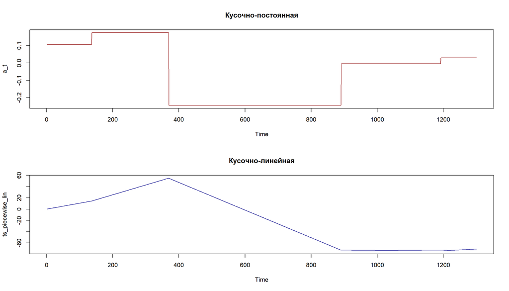

```r
set.seed(5)
lambda <- 5/1000

mean_a <- 0
sd_a <- 0.2

simulate_poisson_process <- function(lambda, T){
  sort(runif(rpois(1, lambda*T), 0, T))
}

breaks <- c(0, simulate_poisson_process(lambda, n), n)
slopes <- rnorm(length(breaks) - 1, mean = mean_a, sd = sd_a)
seg_id <- findInterval(1:n, breaks, rightmost.closed = TRUE)
a_t <- ts(slopes[seg_id])

ts_piecewise_lin <- ts(cumsum(a_t))

par(mfrow=c(2,1))
plot(a_t, type = 'l', col = "darkred", main = 'Кусочно-постоянная')
plot(ts_piecewise_lin, type = 'l',  col = "darkblue", main = 'Кусочно-линейная')
```

#### Итоговый ряд

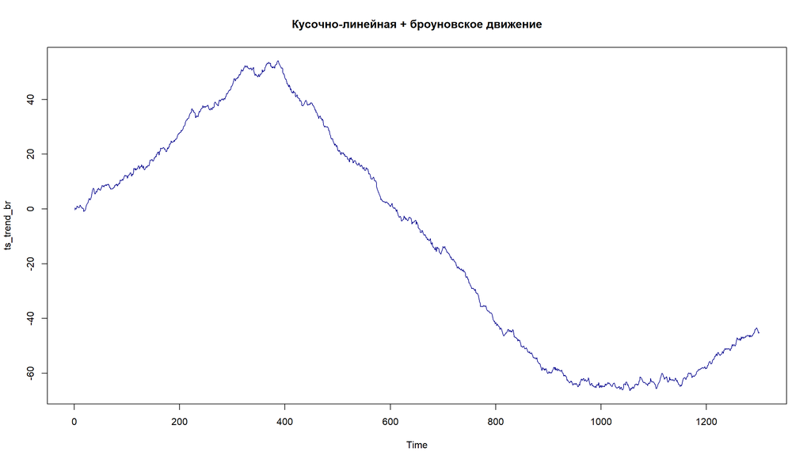

```r
ts_trend_br <- ts_piecewise_lin + ts_br

plot(ts_trend_br, type = 'l',  col = "darkblue", main = 'Кусочно-линейная + броуновское движение')
```

## Прогнозирование

Рассмотрим 4 вида ряда:

1. Линейная функция без шума
2. Кусочно-линейная функция без шума
3. Броуновское движение
4. Кусочно-линейная + броуновское движение

Для них нужно сделать прогноз тремя методами:

1. По последней точке
2. По известному углу наклона
3. По углу наклона, оцененному по m точкам (m — гиперпараметр)

```r
build_trajectory_matrix <- function(y, L = 51) {
  embed(y, L)[, L:1]
}

forecast_last_point <- function(X_row) {
  X_row[length(X_row)-1]
}

forecast_slope_true <- function(X_row, true_slope) {
  last_value <- X_row[length(X_row)-1]
  last_value + true_slope
}

forecast_slope_m <- function(X_row, m) {
  y_hist <- tail(X_row, m + 1)[1:m]

  slope_hat <- mean(diff(y_hist))

  last_value <- X_row[length(X_row)-1]
  last_value + slope_hat
}

evaluate_m <- function(X_row, m_min = 2, m_max = 50) {
  suitable_data <- X_row[-length(X_row)]
  m_best <- m_max
  m <- m_best
  score <- Inf

  data_diff <- diff(suitable_data)
  tr_data <- build_trajectory_matrix(data_diff, m)

  while (m >= m_min) {
    left_data <- matrix(tr_data[, -m], ncol = m-1)
    cur_score <- sum((rowSums(left_data)/(m-1) - tr_data[, m])^2)
    if (cur_score < score) {
      score <- cur_score
      m_best <- m
    }

    m <- m - 1
    tr_data <- tr_data[, -1]
  }

  m_best
}
```

#### Тестирование без подбора m

Как и выше дисперсия тангенса угла наклона $\sigma_a=0,2$, дисперсия шума $\sigma=0,5$, интенсивность изломов $\lambda = \frac{5}{1000}$.

Гиперпараметр $m$ возьмем равным 30.

Тогда для MSE прогноза выполнено $\sigma^2 < \text{MSE} < \sigma^2 + \sigma_a^2$.

```r
set.seed(5)
N <- 500
W <- 51
m <- 30

train <- 750
val <- 250
test <- 250

lambda <- 5/1000

mse_last_lin <- numeric()
mse_last_pc <- numeric()
mse_last_br <- numeric()
mse_last_pc_br <- numeric()

mse_slope_lin <- numeric()
mse_slope_pc <- numeric()
mse_slope_br <- numeric()
mse_slope_pc_br <- numeric()

mse_slope_m_lin <- numeric()
mse_slope_m_pc <- numeric()
mse_slope_m_br <- numeric()
mse_slope_m_pc_br <- numeric()


for (i in 1:N){
  a_lin <- rnorm(1, mean = mean_a, sd = sd_a)
  ts_lin <- ts(a_lin * 1:n) # линейная

  breaks <- c(0, simulate_poisson_process(lambda, n), n)
  slopes <- rnorm(length(breaks) - 1, mean = mean_a, sd = sd_a)
  seg_id <- findInterval(1:n, breaks, rightmost.closed = TRUE)
  a_t <- ts(slopes[seg_id])

  ts_pc <- ts(cumsum(a_t)) # кусочно-линейная

  ts_white_noise <- ts(rnorm(n, mean = mean, sd = sd))
  ts_br <- ts(cumsum(ts_white_noise)) # броуновское

  ts_pc_br <- ts_pc + ts_br # кусочно-линейна + броуновское


  tm_lin <- build_trajectory_matrix(ts_lin, W)
  tm_pc <- build_trajectory_matrix(ts_pc, W)
  tm_br <- build_trajectory_matrix(ts_br, W)
  tm_pc_br <- build_trajectory_matrix(ts_pc_br, W)

  nr = nrow(tm_lin)
  nrib = nr - test + 1

  # по последней точкк
  mse_last_lin[i] <- mean(sapply((nrib):nr, function(j) {
    data <- tm_lin[j, ]
    (forecast_last_point(data) - data[length(data)])^2
  }))

  mse_last_pc[i] <- mean(sapply((nrib):nr, function(j) {
    data <- tm_pc[j, ]
    (forecast_last_point(data) - data[length(data)])^2
  }))

  mse_last_br[i] <- mean(sapply((nrib):nr, function(j) {
    data <- tm_br[j, ]
    (forecast_last_point(data) - data[length(data)])^2
  }))

  mse_last_pc_br[i] <- mean(sapply((nrib):nr, function(j) {
    data <- tm_pc_br[j, ]
    (forecast_last_point(data) - data[length(data)])^2
  }))


  # по известному углу
  mse_slope_lin[i] <- mean(sapply((nrib):nr, function(j) {
    data <- tm_lin[j, ]
    (forecast_slope_true(data, a_lin) - data[length(data)])^2
  }))

  mse_slope_pc[i] <- mean(sapply((nrib):nr, function(j) {
    data <- tm_pc[j, ]
    (forecast_slope_true(data, a_t[length(a_t) - (nr - j)]) - data[length(data)])^2
  }))

  mse_slope_br[i] <- mean(sapply((nrib):nr, function(j) {
    data <- tm_br[j, ]
    (forecast_slope_true(data, 0) - data[length(data)])^2
  }))

  mse_slope_pc_br[i] <- mean(sapply((nrib):nr, function(j) {
    data <- tm_pc_br[j, ]
    (forecast_slope_true(data, a_t[length(a_t) - (nr - j)]) - data[length(data)])^2
  }))



  # по оцененному углу
  mse_slope_m_lin[i] <- mean(sapply((nrib):nr, function(j) {
    data <- tm_lin[j, ]
    (forecast_slope_m(data, m) - data[length(data)])^2
  }))

  mse_slope_m_pc[i] <- mean(sapply((nrib):nr, function(j) {
    data <- tm_pc[j, ]
    (forecast_slope_m(data, m) - data[length(data)])^2
  }))

  mse_slope_m_br[i] <- mean(sapply((nrib):nr, function(j) {
    data <- tm_br[j, ]
    (forecast_slope_m(data, m) - data[length(data)])^2
  }))

  mse_slope_m_pc_br[i] <- mean(sapply((nrib):nr, function(j) {
    data <- tm_pc_br[j, ]
    (forecast_slope_m(data, m) - data[length(data)])^2
  }))

}
```

**Сравнительная таблица при фиксированном m**

```r
summary_mse <- function(x) {
  m  <- mean(x)
  se <- sd(x) / sqrt(length(x))

  data.frame(
    MSE_mean = m,
    CI_low   = m - 1.96 * se,
    CI_high  = m + 1.96 * se
  )
}

results <- list(
  last_lin    = mse_last_lin,
  last_pc     = mse_last_pc,
  last_br     = mse_last_br,
  last_pc_br  = mse_last_pc_br,

  slope_lin   = mse_slope_lin,
  slope_pc    = mse_slope_pc,
  slope_br    = mse_slope_br,
  slope_pc_br = mse_slope_pc_br,

  slope_m_lin   = mse_slope_m_lin,
  slope_m_pc    = mse_slope_m_pc,
  slope_m_br    = mse_slope_m_br,
  slope_m_pc_br = mse_slope_m_pc_br
)

comparison_table <- do.call(
  rbind,
  lapply(names(results), function(name) {

    stats <- summary_mse(results[[name]])

    data.frame(
      Model_Method = name,
      stats
    )
  })
)

rownames(comparison_table) <- NULL
comparison_table$sd_noise <- sd^2
comparison_table$sd_trend <- sd_a^2
comparison_table$sd_noise_trend<- sd^2 + sd_a^2

print_df(comparison_table)
```

| Model_Method | MSE_mean | CI_low | CI_high | sd_noise | sd_trend | sd_noise_trend |
| --- | --- | --- | --- | --- | --- | --- |
| last_lin | 0.03642941147842958 | 0.03219343101344912 | 0.04066539194341003 | 0.25 | 0.04000000000000001 | 0.29 |
| last_pc | 0.03977516347106531 | 0.03563079431875483 | 0.0439195326233758 | 0.25 | 0.04000000000000001 | 0.29 |
| last_br | 0.2488881454291513 | 0.2470054821230158 | 0.2507708087352869 | 0.25 | 0.04000000000000001 | 0.29 |
| last_pc_br | 0.2876836538267067 | 0.28314793903612 | 0.2922193686172934 | 0.25 | 0.04000000000000001 | 0.29 |
| slope_lin | 3.441182408003137e-28 | 2.874920634595899e-28 | 4.007444181410375e-28 | 0.25 | 0.04000000000000001 | 0.29 |
| slope_pc | 1.180457921825097e-28 | 9.859997443913938e-29 | 1.374916099258799e-28 | 0.25 | 0.04000000000000001 | 0.29 |
| slope_br | 0.2488881454291513 | 0.2470054821230158 | 0.2507708087352869 | 0.25 | 0.04000000000000001 | 0.29 |
| slope_pc_br | 0.2488881454291513 | 0.2470054821230158 | 0.2507708087352869 | 0.25 | 0.04000000000000001 | 0.29 |
| slope_m_lin | 3.596230052807323e-28 | 2.947283078320458e-28 | 4.245177027294189e-28 | 0.25 | 0.04000000000000001 | 0.29 |
| slope_m_pc | 0.003734033111284692 | 0.003193740201920063 | 0.004274326020649321 | 0.25 | 0.04000000000000001 | 0.29 |

[output cut: 2 more lines]

На основе графика видно, что моделирование соотносится с теоретическими ожиданиями.

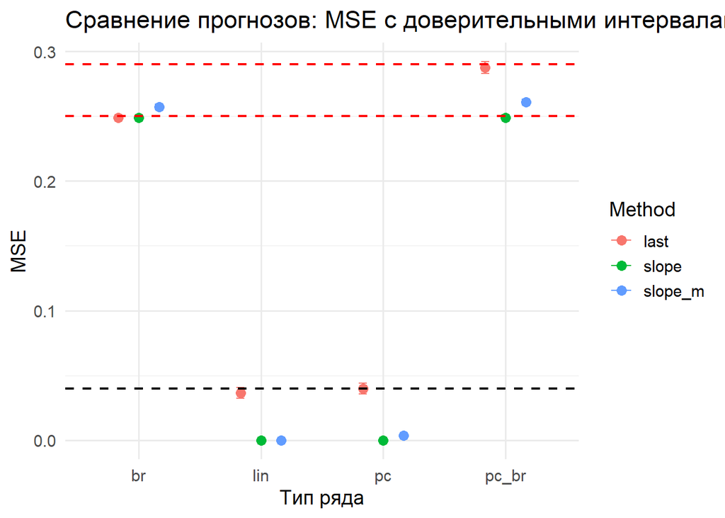

```r
plot_table <- comparison_table |>
  mutate(
    Method = str_extract(Model_Method, "^(last|slope_m|slope)"),
    Series = str_remove(Model_Method, "^(last|slope_m|slope)_")
  ) |>
  select(Series, Method, everything(), -Model_Method)


ggplot(plot_table,
       aes(x = Series,
           y = MSE_mean,
           color = Method)) +

  geom_point(position = position_dodge(width = 0.5),
             size = 3) +

  geom_errorbar(
    aes(ymin = CI_low, ymax = CI_high),
    width = 0.2,
    position = position_dodge(width = 0.5)
  ) +

  geom_hline(yintercept = sd^2,
           linetype = "dashed",
           linewidth = 0.8,
           color = "red") +

  geom_hline(yintercept = sd^2 + sd_a^2,
           linetype = "dashed",
           linewidth = 0.8,
           color = "red") +

  geom_hline(yintercept = sd_a^2,
           linetype = "dashed",
           linewidth = 0.8,
           color = "black") +

  labs(
    title = "Сравнение прогнозов: MSE с доверительными интервалами",
    x = "Тип ряда",
    y = "MSE"
  ) +

  theme_minimal(base_size = 14)
```

Поближе рассмотрим случай с кусочно-линейной + броуновское движение

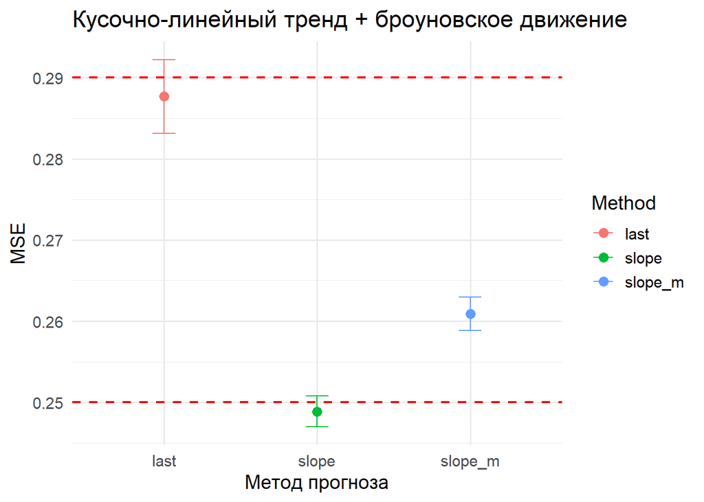

```r
plot_pc_br <- plot_table |>
  filter(Series == "pc_br")

ggplot(plot_pc_br,
       aes(x = Method,
           y = MSE_mean,
           color = Method)) +

  geom_point(size = 3) +

  geom_errorbar(
    aes(ymin = CI_low, ymax = CI_high),
    width = 0.15
  ) +

  geom_hline(yintercept = sd^2,
             linetype = "dashed",
             linewidth = 0.8,
             color = "red") +

  geom_hline(yintercept = sd^2 + sd_a^2,
             linetype = "dashed",
             linewidth = 0.8,
             color = "red") +

  labs(
    title = "Кусочно-линейный тренд + броуновское движение",
    x = "Метод прогноза",
    y = "MSE"
  ) +

  theme_minimal(base_size = 14)
```

#### Тестирование с подбором m

Для начала рассмотрим вариант все с теми же параметрами, что и выше, но добавим прогноз с автоподбором m.

```r
set.seed(5)

mse_slope_auto_lin <- numeric()
mse_slope_auto_pc <- numeric()
mse_slope_auto_br <- numeric()
mse_slope_auto_pc_br <- numeric()

m_lin_sample <- numeric(0)
m_pc_sample <- numeric(0)
m_br_sample <- numeric(0)
m_pc_br_sample <- numeric(0)


for (i in 1:N){
  a_lin <- rnorm(1, mean = mean_a, sd = sd_a)
  ts_lin <- ts(a_lin * 1:n) # линейная

  breaks <- c(0, simulate_poisson_process(lambda, n), n)
  slopes <- rnorm(length(breaks) - 1, mean = mean_a, sd = sd_a)
  seg_id <- findInterval(1:n, breaks, rightmost.closed = TRUE)
  a_t <- ts(slopes[seg_id])

  ts_pc <- ts(cumsum(a_t)) # кусочно-линейная

  ts_white_noise <- ts(rnorm(n, mean = mean, sd = sd))
  ts_br <- ts(cumsum(ts_white_noise)) # броуновское

  ts_pc_br <- ts_pc + ts_br # кусочно-линейна + броуновское


  tm_lin <- build_trajectory_matrix(ts_lin, W)
  tm_pc <- build_trajectory_matrix(ts_pc, W)
  tm_br <- build_trajectory_matrix(ts_br, W)
  tm_pc_br <- build_trajectory_matrix(ts_pc_br, W)

  nr = nrow(tm_lin)
  nrib = nr - test + 1

  #подбираем m на валидационной части
  m_lin <- evaluate_m(tm_lin[(train+1):(nrib-1), 1])
  m_pc <- evaluate_m(tm_pc[(train+1):(nrib-1), 1])
  m_br <- evaluate_m(tm_br[(train+1):(nrib-1), 1])
  m_pc_br <- evaluate_m(tm_pc_br[(train+1):(nrib-1), 1])

  m_lin_sample <<- c(m_lin_sample, m_lin)
  m_pc_sample <<- c(m_pc_sample, m_pc)
  m_br_sample <<- c(m_br_sample, m_br)
  m_pc_br_sample <<- c(m_pc_br_sample, m_pc_br)


  # по оцененному углу
  mse_slope_auto_lin[i] <- mean(sapply((nrib):nr, function(j) {
    data <- tm_lin[j, ]
    (forecast_slope_m(data, m_lin) - data[length(data)])^2
  }))

  mse_slope_auto_pc[i] <- mean(sapply((nrib):nr, function(j) {
    data <- tm_pc[j, ]
    (forecast_slope_m(data, m_pc) - data[length(data)])^2
  }))

  mse_slope_auto_br[i] <- mean(sapply((nrib):nr, function(j) {
    data <- tm_br[j, ]
    (forecast_slope_m(data, m_br) - data[length(data)])^2
  }))

  mse_slope_auto_pc_br[i] <- mean(sapply((nrib):nr, function(j) {
    data <- tm_pc_br[j, ]
    (forecast_slope_m(data, m_pc_br) - data[length(data)])^2
  }))

}
```

```r
summary_mse <- function(x) {
  m  <- mean(x)
  se <- sd(x) / sqrt(length(x))

  data.frame(
    MSE_mean = m,
    CI_low   = m - 1.96 * se,
    CI_high  = m + 1.96 * se
  )
}

results <- list(
  last_lin    = mse_last_lin,
  last_pc     = mse_last_pc,
  last_br     = mse_last_br,
  last_pc_br  = mse_last_pc_br,

  slope_lin   = mse_slope_lin,
  slope_pc    = mse_slope_pc,
  slope_br    = mse_slope_br,
  slope_pc_br = mse_slope_pc_br,

  slope_m_lin   = mse_slope_m_lin,
  slope_m_pc    = mse_slope_m_pc,
  slope_m_br    = mse_slope_m_br,
  slope_m_pc_br = mse_slope_m_pc_br,

  slope_auto_lin   = mse_slope_auto_lin,
  slope_auto_pc    = mse_slope_auto_pc,
  slope_auto_br    = mse_slope_auto_br,
  slope_auto_pc_br = mse_slope_auto_pc_br
)

comparison_table <- do.call(
  rbind,
  lapply(names(results), function(name) {

    stats <- summary_mse(results[[name]])

    data.frame(
      Model_Method = name,
      stats
    )
  })
)

rownames(comparison_table) <- NULL
comparison_table$sd_noise <- sd^2
comparison_table$sd_trend <- sd_a^2
comparison_table$sd_noise_trend<- sd^2 + sd_a^2

print_df(comparison_table)
```

| Model_Method | MSE_mean | CI_low | CI_high | sd_noise | sd_trend | sd_noise_trend |
| --- | --- | --- | --- | --- | --- | --- |
| last_lin | 0.03642941147842958 | 0.03219343101344912 | 0.04066539194341003 | 0.25 | 0.04000000000000001 | 0.29 |
| last_pc | 0.03977516347106531 | 0.03563079431875483 | 0.0439195326233758 | 0.25 | 0.04000000000000001 | 0.29 |
| last_br | 0.2488881454291513 | 0.2470054821230158 | 0.2507708087352869 | 0.25 | 0.04000000000000001 | 0.29 |
| last_pc_br | 0.2876836538267067 | 0.28314793903612 | 0.2922193686172934 | 0.25 | 0.04000000000000001 | 0.29 |
| slope_lin | 3.441182408003137e-28 | 2.874920634595899e-28 | 4.007444181410375e-28 | 0.25 | 0.04000000000000001 | 0.29 |
| slope_pc | 1.180457921825097e-28 | 9.859997443913938e-29 | 1.374916099258799e-28 | 0.25 | 0.04000000000000001 | 0.29 |
| slope_br | 0.2488881454291513 | 0.2470054821230158 | 0.2507708087352869 | 0.25 | 0.04000000000000001 | 0.29 |
| slope_pc_br | 0.2488881454291513 | 0.2470054821230158 | 0.2507708087352869 | 0.25 | 0.04000000000000001 | 0.29 |
| slope_m_lin | 3.596230052807323e-28 | 2.947283078320458e-28 | 4.245177027294189e-28 | 0.25 | 0.04000000000000001 | 0.29 |
| slope_m_pc | 0.003734033111284692 | 0.003193740201920063 | 0.004274326020649321 | 0.25 | 0.04000000000000001 | 0.29 |

[output cut: 6 more lines]

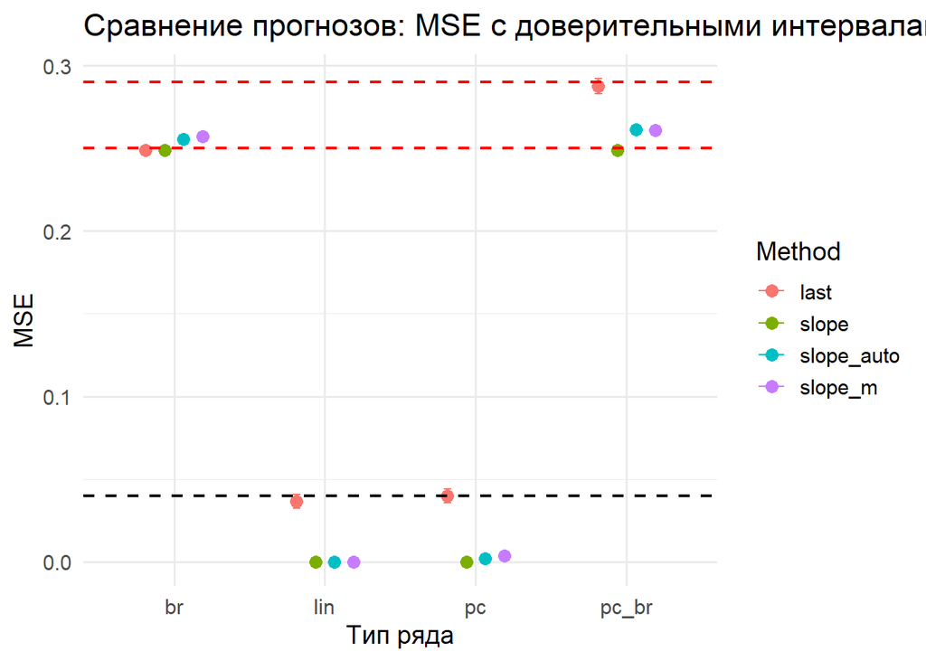

```r
plot_table_2 <- comparison_table |>
  mutate(
    Method = str_extract(Model_Method, "^(last|slope_m|slope_auto|slope)"),
    Series = str_remove(Model_Method, "^(last|slope_m|slope_auto|slope)_")
  ) |>
  select(Series, Method, everything(), -Model_Method)


ggplot(plot_table_2,
       aes(x = Series,
           y = MSE_mean,
           color = Method)) +

  geom_point(position = position_dodge(width = 0.5),
             size = 3) +

  geom_errorbar(
    aes(ymin = CI_low, ymax = CI_high),
    width = 0.2,
    position = position_dodge(width = 0.5)
  ) +

  geom_hline(yintercept = sd^2,
           linetype = "dashed",
           linewidth = 0.8,
           color = "red") +

  geom_hline(yintercept = sd^2 + sd_a^2,
           linetype = "dashed",
           linewidth = 0.8,
           color = "red") +

  geom_hline(yintercept = sd_a^2,
           linetype = "dashed",
           linewidth = 0.8,
           color = "black") +

  labs(
    title = "Сравнение прогнозов: MSE с доверительными интервалами",
    x = "Тип ряда",
    y = "MSE"
  ) +

  theme_minimal(base_size = 14)
```

Снова посмотрим на модельный ряд

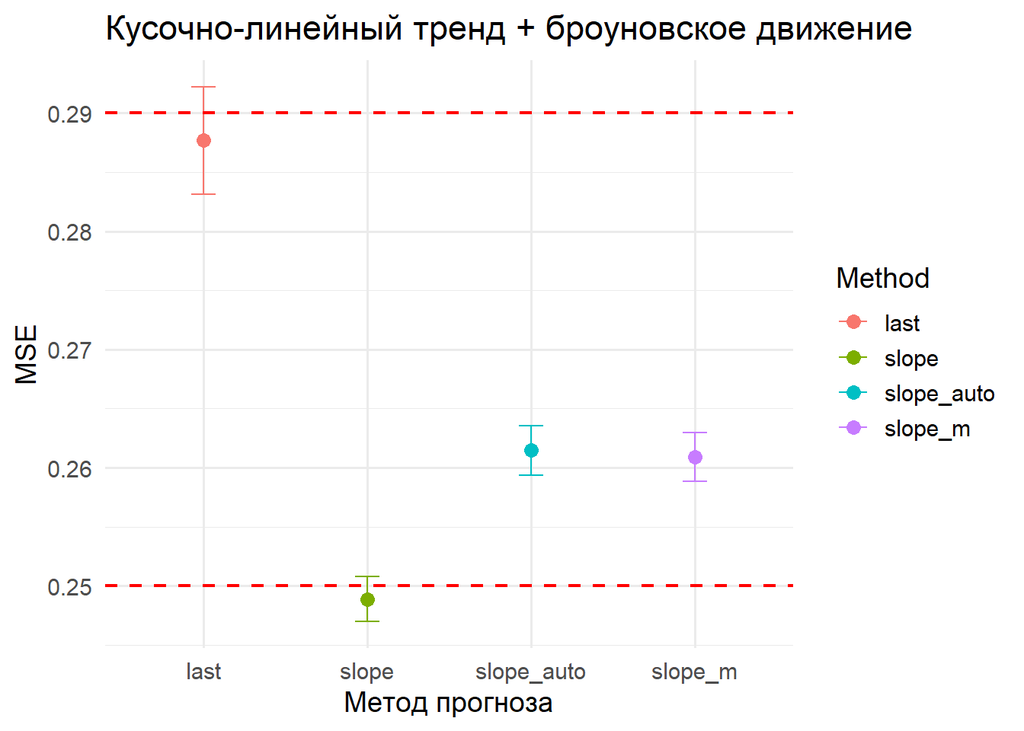

```r
plot_pc_br_2 <- plot_table_2 |>
  filter(Series == "pc_br")

ggplot(plot_pc_br_2,
       aes(x = Method,
           y = MSE_mean,
           color = Method)) +

  geom_point(size = 3) +

  geom_errorbar(
    aes(ymin = CI_low, ymax = CI_high),
    width = 0.15
  ) +

  geom_hline(yintercept = sd^2,
             linetype = "dashed",
             linewidth = 0.8,
             color = "red") +

  geom_hline(yintercept = sd^2 + sd_a^2,
             linetype = "dashed",
             linewidth = 0.8,
             color = "red") +
  labs(
    title = "Кусочно-линейный тренд + броуновское движение",
    x = "Метод прогноза",
    y = "MSE"
  ) +

  theme_minimal(base_size = 14)
```

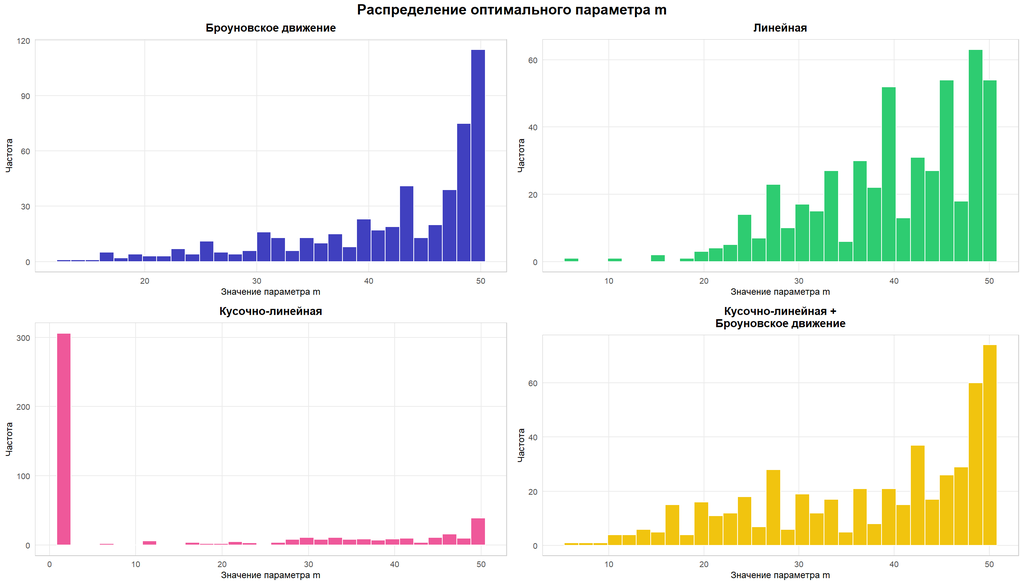

```r
sample_labels <- c(
  "Br" = "Броуновское движение",
  "Lin" = "Линейная",
  "PC" = "Кусочно-линейная",
  "PC_Br" = "Кусочно-линейная +\nБроуновское движение"
)

df <- data.frame(
  Br = m_br_sample,
  Lin = m_lin_sample,
  PC = m_pc_sample,
  PC_Br = m_pc_br_sample
) %>%
  pivot_longer(cols = everything(), names_to = "Sample", values_to = "Value") %>%
  mutate(Sample_RU = recode(Sample, !!!sample_labels))

colors <- c("#4040bf", "#2ecc71", "#ef589a", "#f1c40f")
names(colors) <- c("Br", "Lin", "PC", "PC_Br")

plots <- list()
sample_names <- unique(df$Sample)

for(i in seq_along(sample_names)) {
  sample_code <- sample_names[i]
  sample_data <- df %>% filter(Sample == sample_code)

  p <- ggplot(sample_data, aes(x = Value)) +
    geom_histogram(fill = colors[sample_code], color = "white", bins = 30) +
    labs(
      title = sample_labels[sample_code],
      x = "Значение параметра m",
      y = "Частота"
    ) +
    theme_minimal() +
    theme(
      plot.title = element_text(hjust = 0.5, size = 11, face = "bold"),
      axis.title = element_text(size = 9),
      axis.text = element_text(size = 8),
      panel.grid.minor = element_blank(),
      panel.border = element_rect(fill = NA, color = "gray80"),
      plot.margin = margin(5, 5, 5, 5)
    )

  plots[[i]] <- p
}

title_grob <- textGrob(
  "Распределение оптимального параметра m",
  gp = gpar(fontsize = 14, fontface = "bold"),
  hjust = 0.5
)

grid.arrange(
  grobs = plots,
  ncol = 2,
  nrow = 2,
  top = title_grob
)
```

В случае $\lambda=\frac{5}{1000}$, получаем что для ряда длины 1300 количество изломов будет примерно равно 6, то есть тренд меняется относительно редко. Дисперсия угла наклона в данном случае меньше, чем дирсперсия шума.

В модели броуновского движения тренд отсутствует, однако если взять малое m, то ряд может выглядеть как имеющий тренд. Поэтому при малых значениях окна оценка наклона основывается на небольшом числе наблюдений и имеет большую дисперсию, что приводит к переобучению на шуме. При увеличении m оценка наклона усредняет случайные колебания и становится близкой к нулю. Поэтому оптимальное m чаще всего принимает большие значения.

Малые значения m возникают в случаях, когда в окно попадает точка излома тренда, поэтому для кусочно-линейной функции чаще m принимает маленькие значения.

Для модельного ряда кусочно-линейная + броуновское оптимальное значение окна определяется компромиссом между подавлением шума и адаптацией к изменениям наклона.

### Изменение параметров

**Изменение интенсивности изломов**

```r
set.seed(5)

lambda_grid <- c(
  2/1000,
  5/1000,
  15/1000
)

results <- data.frame()
m_values <- data.frame()

for (lambda in lambda_grid) {

  mse_sample <- numeric(N)
  m_sample <- numeric(0)

  for (i in 1:N) {
    breaks <- c(0, simulate_poisson_process(lambda, n), n)
    slopes <- rnorm(length(breaks) - 1, mean = mean_a, sd = sd_a)
    seg_id <- findInterval(1:n, breaks, rightmost.closed = TRUE)
    a_t <- ts(slopes[seg_id])

    ts_pc <- ts(cumsum(a_t))

    ts_white_noise <- ts(rnorm(n, mean = mean, sd = sd))
    ts_br <- ts(cumsum(ts_white_noise))

    ts_pc_br <- ts_pc + ts_br

    tm <- build_trajectory_matrix(ts_pc_br, W)

    nr <- nrow(tm)
    nrib <- nr - test + 1

    m_opt <- evaluate_m(tm[(train+1):(nrib-1), 1])

    m_sample <- c(m_sample, m_opt)
    m_values <- rbind(
      m_values,
      data.frame(lambda=lambda, m=m_opt)
    )

    mse_sample[i] <- mean(sapply((nrib):nr, function(j) {
      data <- tm[j, ]
      (forecast_slope_m(data, m_opt) - data[length(data)])^2
    }))
  }

  mse_mean <- mean(mse_sample)
  mse_sd <- sd(mse_sample)

  CI_low <- mse_mean - 1.96 * mse_sd / sqrt(N)
  CI_high <- mse_mean + 1.96 * mse_sd / sqrt(N)

  results <- rbind(
    results,
    data.frame(
      lambda=lambda,
      Method="slope_auto",
      MSE_mean=mse_mean,
      CI_low=CI_low,
      CI_high=CI_high
    )
  )
}
```

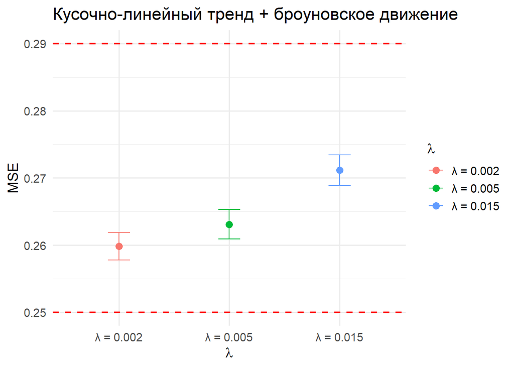

```r
results$lambda <- factor(results$lambda,
                         labels=c("λ = 0.002",
                                  "λ = 0.005",
                                  "λ = 0.015"))

m_values$lambda <- factor(m_values$lambda,
                          labels=c("λ = 0.002",
                                   "λ = 0.005",
                                   "λ = 0.015"))

ggplot(results,
       aes(x = factor(lambda),
           y = MSE_mean,
           color = factor(lambda),
           group = Method)) +

  geom_point(position = position_dodge(width = 0.5), size = 3) +

  geom_errorbar(
    aes(ymin = CI_low, ymax = CI_high),
    width = 0.2,
    position = position_dodge(width = 0.5)
  ) +

  geom_hline(yintercept = sd^2,
             linetype = "dashed",
             linewidth = 0.8,
             color = "red") +

  geom_hline(yintercept = sd^2 + sd_a^2,
             linetype = "dashed",
             linewidth = 0.8,
             color = "red") +

  labs(
    title = "Кусочно-линейный тренд + броуновское движение",
    x = expression(lambda),
    y = "MSE",
    color = expression(lambda)
  ) +

  theme_minimal(base_size = 14)
```

*Гистограммы для оптимального m*

По графикам видно, что чем чаще изломы, тем меньше оптимальное m: для меньшего $\lambda = 0,002$ большие значения m выбираются чаще, чем для большего.

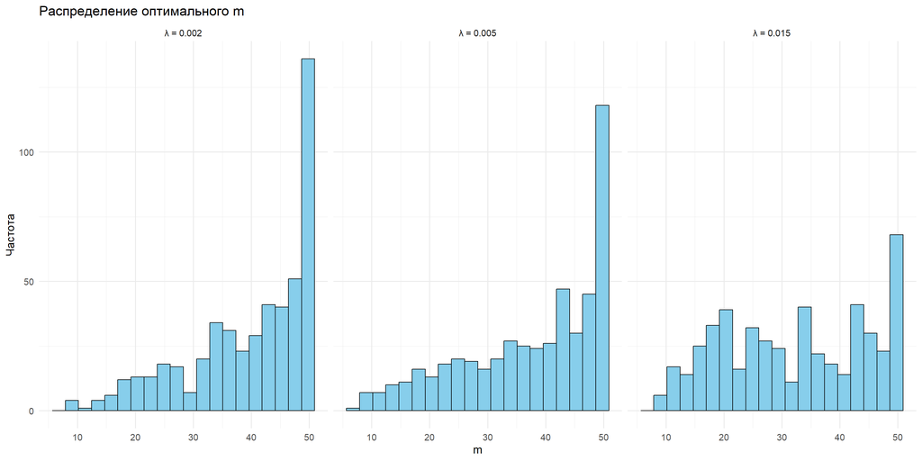

```r
ggplot(m_values,
             aes(x = m)) +

  geom_histogram(
    bins = 20,
    fill = "skyblue",
    color = "black"
  ) +

  facet_wrap(~lambda, nrow = 1) +

  labs(
    title = "Распределение оптимального m",
    x = "m",
    y = "Частота"
  ) +

  theme_minimal(base_size = 14)
```

**Изменение дисперсии шума**

```r
sd_grid <- c(
  0.15,
  0.5,
  1
)

lambda <- 5/1000

set.seed(5)

results <- data.frame()
m_values <- data.frame()

for (sd in sd_grid) {

  mse_sample <- numeric(N)
  m_sample <- numeric(0)

  for (i in 1:N) {
    breaks <- c(0, simulate_poisson_process(lambda, n), n)
    slopes <- rnorm(length(breaks) - 1, mean = mean_a, sd = sd_a)
    seg_id <- findInterval(1:n, breaks, rightmost.closed = TRUE)
    a_t <- ts(slopes[seg_id])

    ts_pc <- ts(cumsum(a_t))

    ts_white_noise <- ts(rnorm(n, mean = mean, sd = sd))
    ts_br <- ts(cumsum(ts_white_noise))

    ts_pc_br <- ts_pc + ts_br

    tm <- build_trajectory_matrix(ts_pc_br, W)

    nr <- nrow(tm)
    nrib <- nr - test + 1

    m_opt <- evaluate_m(tm[(train+1):(nrib-1), 1])

    m_sample <- c(m_sample, m_opt)
    m_values <- rbind(
      m_values,
      data.frame(sd=sd, m=m_opt)
    )

    mse_sample[i] <- mean(sapply((nrib):nr, function(j) {
      data <- tm[j, ]
      (forecast_slope_m(data, m_opt) - data[length(data)])^2
    }))
  }

  mse_mean <- mean(mse_sample)
  mse_sd <- sd(mse_sample)

  CI_low <- mse_mean - 1.96 * mse_sd / sqrt(N)
  CI_high <- mse_mean + 1.96 * mse_sd / sqrt(N)

  results <- rbind(
    results,
    data.frame(
      sd=sd,
      Method="slope_auto",
      MSE_mean=mse_mean,
      CI_low=CI_low,
      CI_high=CI_high
    )
  )
}
```

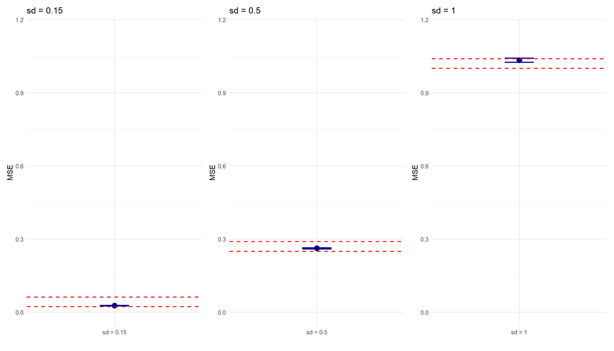

```r
results$sd <- factor(results$sd,
                         labels=c("sd = 0.15",
                                  "sd = 0.5",
                                  "sd = 1"))

m_values$sd <- factor(m_values$sd,
                          labels=c("sd = 0.15",
                                   "sd = 0.5",
                                   "sd = 1"))

plots <- list()

for (val in levels(results$sd)) {

  res_subset <- results[results$sd == val, ]
  sd_val <- as.numeric(gsub("sd = ", "", val))

  p <- ggplot(res_subset) +
    geom_point(aes(x = sd, y = MSE_mean),
               size = 4, color = "darkblue") +

    geom_errorbar(aes(x = sd, ymin = CI_low, ymax = CI_high),
                  width = 0.2, linewidth = 1, color = "darkblue") +

    geom_hline(yintercept = sd_val^2,
               linetype = "dashed", linewidth = 0.8, color = "red") +
    geom_hline(yintercept = sd_val^2 + sd_a^2,
               linetype = "dashed", linewidth = 0.8, color = "red") +

    labs(title = val, x = "", y = "MSE") +
    ylim(0, max(results$CI_high) * 1.1) +
    theme_minimal(base_size = 12)

  plots[[val]] <- p
}

wrap_plots(plots, ncol = 3)
```

*Гистограммы для оптимального m*

По графику видно, что чем больше шум, тем больше оптимальное m: нужно большее окно, чтобы сгладить влияние шума.

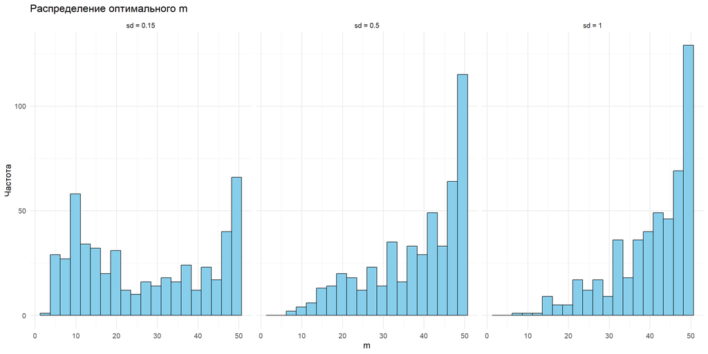

```r
ggplot(m_values,
             aes(x = m)) +

  geom_histogram(
    bins = 20,
    fill = "skyblue",
    color = "black"
  ) +

  facet_wrap(~sd, nrow = 1) +

  labs(
    title = "Распределение оптимального m",
    x = "m",
    y = "Частота"
  ) +

  theme_minimal(base_size = 14)
```